# STOR 455 Content: Data Analysis

# Logistic Regression

1. Binary Response (0 or 1)
2. Ordinal Response (Yes, Maybe, No)
3. Nominal Response (Green, Blue, Red)

## Binary Logistic Regression

–> Code the response Y as a (0,1) dummy (indicator) variable.

## Example with **one** quantitative variable

```r
modH=lm(Gender~Hgt,data=Pulsef17)
summary(modH)
```

```
##
## Call:
## lm(formula = Gender ~ Hgt, data = Pulsef17)
##
## Residuals:
##      Min       1Q   Median       3Q      Max
## -1.26900 -0.26306  0.01128  0.27969  0.82838
##
## Coefficients:
##              Estimate Std. Error t value Pr(>|t|)
## (Intercept)  6.755899   0.311532   21.69   <2e-16 ***
## Hgt         -0.091448   0.004549  -20.10   <2e-16 ***
## ---
## Signif. codes:  0 '***' 0.001 '**' 0.01 '*' 0.05 '.' 0.1 ' ' 1
##
## Residual standard error: 0.3473 on 373 degrees of freedom
## Multiple R-squared:   0.52,  Adjusted R-squared:  0.5187
## F-statistic: 404.1 on 1 and 373 DF,  p-value: < 2.2e-16
```

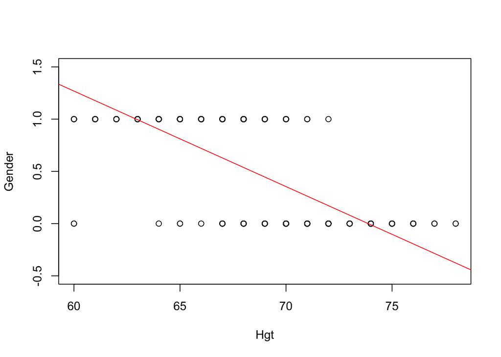

```r
plot(Gender~Hgt,ylim=c(-0.5,1.5),data=Pulsef17)
abline(modH,col= "red")
```

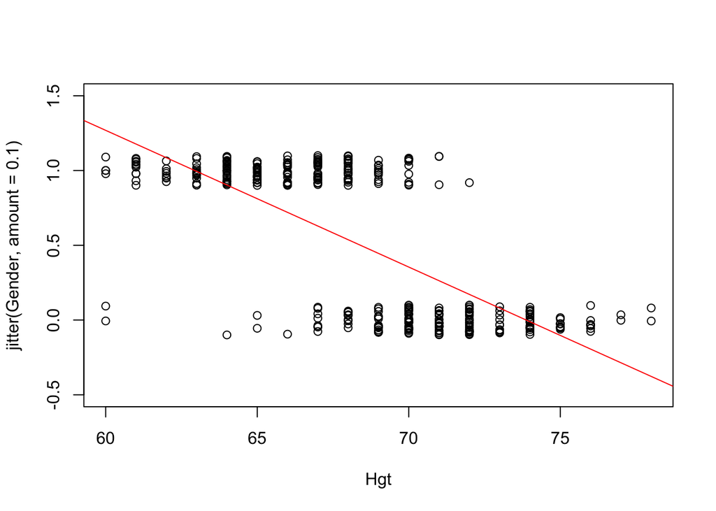

```r
plot(jitter(Gender,amount=0.1)~Hgt,ylim=c(-0.5,1.5), data=Pulsef17)
 abline(modH,col="red")
```

In ordinary regression the model predicts the mean Y for any combination of predictors.Goal of logistic regression: Predict the “true” **proportion of success**, π, at any value of the predictor.

## Better Form **Logit glm** function

Provides a deviance analysis and the “estimate” is the proportion of success

```r
data("Putts1")

modPutt=glm(Made~Length,family=binomial,data=Putts1)
summary(modPutt)
```

```
##
## Call:
## glm(formula = Made ~ Length, family = binomial, data = Putts1)
##
## Deviance Residuals:
##     Min       1Q   Median       3Q      Max
## -1.8705  -1.1186   0.6181   1.0026   1.4882
##
## Coefficients:
##             Estimate Std. Error z value Pr(>|z|)
## (Intercept)  3.25684    0.36893   8.828   <2e-16 ***
## Length      -0.56614    0.06747  -8.391   <2e-16 ***
## ---
## Signif. codes:  0 '***' 0.001 '**' 0.01 '*' 0.05 '.' 0.1 ' ' 1
##
## (Dispersion parameter for binomial family taken to be 1)
##
##     Null deviance: 800.21  on 586  degrees of freedom
## Residual deviance: 719.89  on 585  degrees of freedom
## AIC: 723.89
##
## Number of Fisher Scoring iterations: 4
```

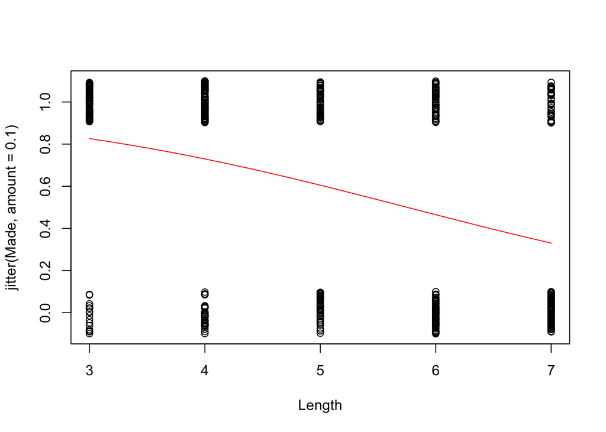

```r
B0 = summary(modPutt)$coef[1]
B1 = summary(modPutt)$coef[2]

plot(jitter(Made,amount=0.1)~Length,data=Putts1)
curve(exp(B0+B1*x)/(1+exp(B0+B1*x)),add=TRUE, col="red")
```

```r
#Odds Ratio
exp(B1)
```

```
## [1] 0.5677116
```

```r
#Confidence interval for slope/odds ratio
SE_B1 = summary(modPutt)$coef[2,2]
exp(B1 - SE_B1*qnorm(0.975))
```

```
## [1] 0.4973894
```

```r
exp(B1 + SE_B1*qnorm(0.975))
```

```
## [1] 0.6479761
```

```r
exp(confint.default(modPutt))
```

```
##                  2.5 %     97.5 %
## (Intercept) 12.6006177 53.5133410
## Length       0.4973894  0.6479761
```

## Comparing Logistic Models

Coefficients are chosen to minimize the sum of the squared errors in the observed sample. Overall Test null hypothesis: How much “better” does the linear model do than one with a constant ( mean evaluation)?

Parameters are chosen to maximize the likelihood of the observed sample. Measure likelihood through **Residual Deviance**

How much “improvement” with the predictor? **G-statistic** ->Want the highests G-stat, difference between the null and residual deviance -> Evaluated with chi-square test

```r
lmodPutt=glm(Made~Length,family=binomial,data=Putts1)
summary(lmodPutt)
```

```
##
## Call:
## glm(formula = Made ~ Length, family = binomial, data = Putts1)
##
## Deviance Residuals:
##     Min       1Q   Median       3Q      Max
## -1.8705  -1.1186   0.6181   1.0026   1.4882
##
## Coefficients:
##             Estimate Std. Error z value Pr(>|z|)
## (Intercept)  3.25684    0.36893   8.828   <2e-16 ***
## Length      -0.56614    0.06747  -8.391   <2e-16 ***
## ---
## Signif. codes:  0 '***' 0.001 '**' 0.01 '*' 0.05 '.' 0.1 ' ' 1
##
## (Dispersion parameter for binomial family taken to be 1)
##
##     Null deviance: 800.21  on 586  degrees of freedom
## Residual deviance: 719.89  on 585  degrees of freedom
## AIC: 723.89
##
## Number of Fisher Scoring iterations: 4
```

```r
1-pchisq(80,1)
```

```
## [1] 0
```

P-value is 0, reject null hypothesis

## Nested LRT for Logistic Regression (Likelihood Ratio Test)

Is the improvement, change in –2loga(𝐿), “significant” for the number of extra predictors?

```r
Full=glm(Gender~Hgt+Wgt+I(Hgt^2)+I(Wgt^2)+I(Hgt*Wgt),family=binomial, data=Pulsef17)
summary(Full)
```

```
##
## Call:
## glm(formula = Gender ~ Hgt + Wgt + I(Hgt^2) + I(Wgt^2) + I(Hgt *
##     Wgt), family = binomial, data = Pulsef17)
##
## Deviance Residuals:
##     Min       1Q   Median       3Q      Max
## -2.9982  -0.2922   0.1303   0.4437   2.4720
##
## Coefficients:
##                Estimate Std. Error z value Pr(>|z|)
## (Intercept)  -2.730e+02  8.685e+01  -3.143 0.001671 **
## Hgt           8.890e+00  2.677e+00   3.321 0.000896 ***
## Wgt          -5.092e-02  3.171e-01  -0.161 0.872420
## I(Hgt^2)     -6.890e-02  2.220e-02  -3.103 0.001915 **
## I(Wgt^2)      1.728e-04  4.439e-04   0.389 0.697073
## I(Hgt * Wgt) -8.151e-04  5.549e-03  -0.147 0.883209
## ---
## Signif. codes:  0 '***' 0.001 '**' 0.01 '*' 0.05 '.' 0.1 ' ' 1
##
## (Dispersion parameter for binomial family taken to be 1)
##
##     Null deviance: 519.84  on 374  degrees of freedom
## Residual deviance: 212.15  on 369  degrees of freedom
## AIC: 224.15
##
## Number of Fisher Scoring iterations: 7
```

```r
Reduced=glm(Gender~Hgt+Wgt,family=binomial,data=Pulsef17)
summary(Reduced)
```

```
##
## Call:
## glm(formula = Gender ~ Hgt + Wgt, family = binomial, data = Pulsef17)
##
## Deviance Residuals:
##     Min       1Q   Median       3Q      Max
## -3.2190  -0.3727   0.0546   0.4285   2.5418
##
## Coefficients:
##             Estimate Std. Error z value Pr(>|z|)
## (Intercept) 43.64006    5.39495   8.089 6.01e-16 ***
## Hgt         -0.51669    0.08434  -6.127 8.98e-10 ***
## Wgt         -0.05331    0.01089  -4.895 9.82e-07 ***
## ---
## Signif. codes:  0 '***' 0.001 '**' 0.01 '*' 0.05 '.' 0.1 ' ' 1
##
## (Dispersion parameter for binomial family taken to be 1)
##
##     Null deviance: 519.84  on 374  degrees of freedom
## Residual deviance: 223.59  on 372  degrees of freedom
## AIC: 229.59
##
## Number of Fisher Scoring iterations: 6
```

Change in Residual Deviance: (Reduced Resid Deviance- Full Resid Deviance) 223.59-212.15=11.44 with 3 df(difference in df for each model’s residual deviance)

```r
GstatA = 307.69
GstatB = 296.25
1-pchisq(11.44,3)
```

```
## [1] 0.009569722
```

null hypothesis: The addiitonal variables do not add significance to the model alternate hypothesis: At least one of the additional variables adds significance to the model

P-value < 0.5 so the null hypothesis is rejected, at least one of the additional variables adds significance to the model

# Anova for Means

# Compare means for each factor of the variable (Does one aspect of the variable have a more significant effect on the prediction than others?)

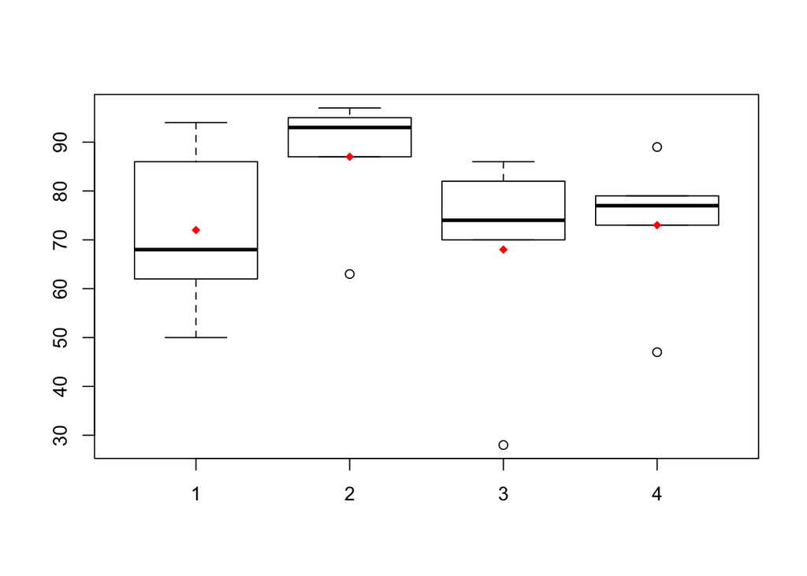

```r
Exams4 <- read.csv("/Users/abwilli/Downloads/Exams4.csv")
boxplot(Grade~Exam, data=Exams4)
means = tapply(Exams4$Grade,Exams4$Exam,mean)
points(means,col="red",pch=18)
```

```r
#summaries = tapply(newData$price, newData$model, summary)
#means = tapply(newData$price, newData$model, mean)
#sds = tapply(newData$price, newData$model, sd)
```

## One way Anova

```r
amodG=aov(Grade~factor(Exam),data=Exams4)
summary(amodG)
```

```
##              Df Sum Sq Mean Sq F value Pr(>F)
## factor(Exam)  3   1030   343.3   1.056  0.395
## Residuals    16   5200   325.0
```

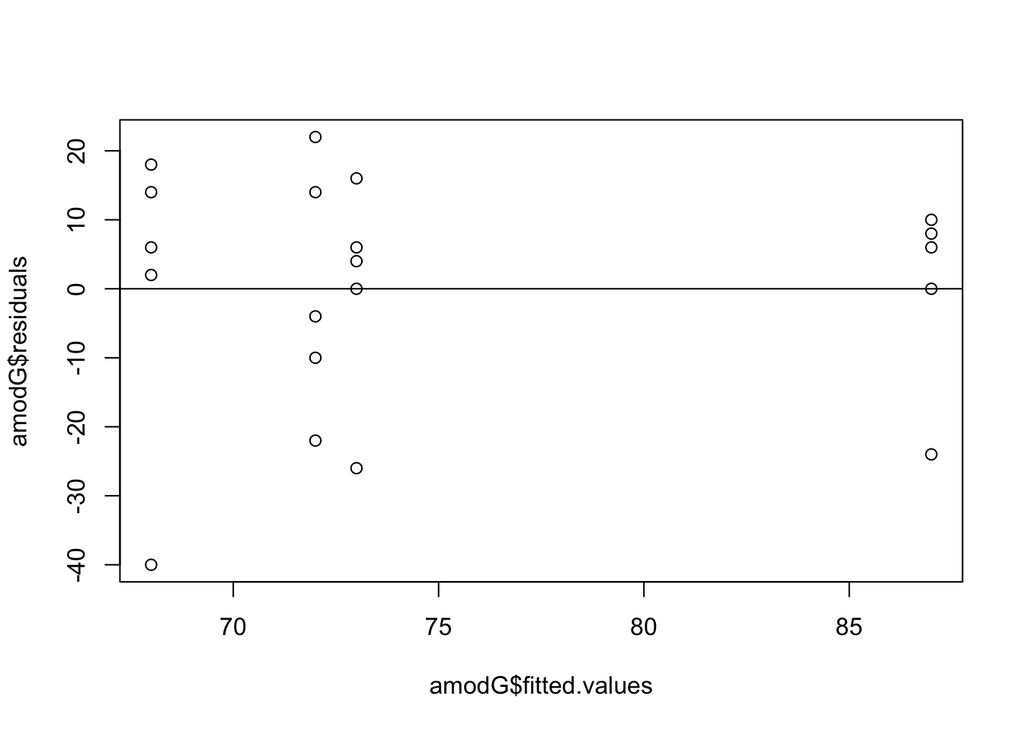

```r
plot(amodG$residuals~amodG$fitted.values)
abline(0,0)
```

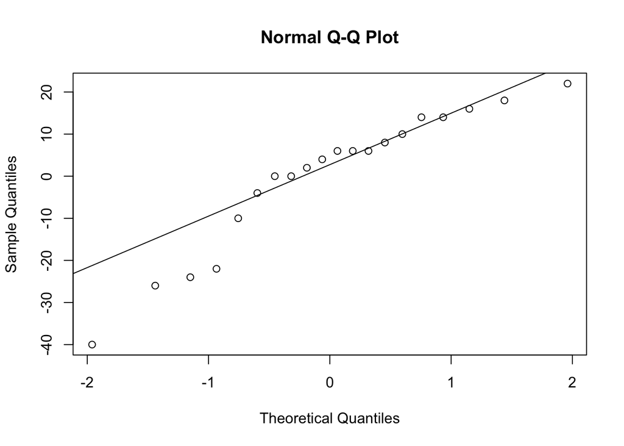

```r
qqnorm(amodG$residuals)
qqline(amodG$residuals)
```

```r
tapply(Exams4$Grade,Exams4$Student,mean)
```

```
##  Barb Betsy  Bill   Bob   Bud
##    75    91    79    83    47
```

null hypothesis: There is no significant difference among the means of each group alternate hypothesis: There is a significant difference among the means of each group

Which means are significantly different? -Use pairwise comparisons (means considered different at a 5% level- aka a 95% confidence interval)

Pairwise Comparisons

```r
#Fisher's LSD
pairwise.t.test(Exams4$Grade,Exams4$Student,p.adj="none")
```

```
##
##  Pairwise comparisons using t tests with pooled SD
##
## data:  Exams4$Grade and Exams4$Student
##
##       Barb    Betsy   Bill    Bob
## Betsy 0.05357 -       -       -
## Bill  0.60812 0.13699 -       -
## Bob   0.31148 0.31148 0.60812 -
## Bud   0.00229 3.8e-05 0.00079 0.00028
##
## P value adjustment method: none
```

```r
#Bonferroni Adjusted
pairwise.t.test(Exams4$Grade,Exams4$Student,p.adj="bonf")
```

```
##
##  Pairwise comparisons using t tests with pooled SD
##
## data:  Exams4$Grade and Exams4$Student
##
##       Barb    Betsy   Bill    Bob
## Betsy 0.53567 -       -       -
## Bill  1.00000 1.00000 -       -
## Bob   1.00000 1.00000 1.00000 -
## Bud   0.02293 0.00038 0.00789 0.00277
##
## P value adjustment method: bonferroni
```

```r
#Tukey HSD-BEST MEDAL
#TukeyHSD(modS)

#plot Tukey
#origpar=par()          #saves current graphic parameters
#par(mar=c(4,7,3,1))    #adjusts margins for wider labels
#hsd=TukeyHSD(modS)     #save the Tukey  intervals
#plot(hsd,las=2)        #plot the intervals
#par(origpar)           #restore graph settings
```

## Two-Way

-Can we use BOTH factors (Exams and Students) to help explain the variability in the exam scores?

```r
amodC=aov(Grade~factor(Exam)+Student,data=Exams4)
summary(amodC)
```

```
##              Df Sum Sq Mean Sq F value   Pr(>F)
## factor(Exam)  3   1030   343.3   5.722   0.0114 *
## Student       4   4480  1120.0  18.667 4.35e-05 ***
## Residuals    12    720    60.0
## ---
## Signif. codes:  0 '***' 0.001 '**' 0.01 '*' 0.05 '.' 0.1 ' ' 1
```

```r
TukeyHSD(amodC)
```

```
##   Tukey multiple comparisons of means
##     95% family-wise confidence level
##
## Fit: aov(formula = Grade ~ factor(Exam) + Student, data = Exams4)
##
## $`factor(Exam)`
##     diff         lwr        upr     p adj
## 2-1   15   0.4554143 29.5445857 0.0425678
## 3-1   -4 -18.5445857 10.5445857 0.8455825
## 4-1    1 -13.5445857 15.5445857 0.9968212
## 3-2  -19 -33.5445857 -4.4554143 0.0102092
## 4-2  -14 -28.5445857  0.5445857 0.0605331
## 4-3    5  -9.5445857 19.5445857 0.7409734
##
## $Student
##            diff        lwr        upr     p adj
## Betsy-Barb   16  -1.458285  33.458285 0.0782719
## Bill-Barb     4 -13.458285  21.458285 0.9451946
## Bob-Barb      8  -9.458285  25.458285 0.6039841
## Bud-Barb    -28 -45.458285 -10.541715 0.0019421
## Bill-Betsy  -12 -29.458285   5.458285 0.2467758
## Bob-Betsy    -8 -25.458285   9.458285 0.6039841
## Bud-Betsy   -44 -61.458285 -26.541715 0.0000293
## Bob-Bill      4 -13.458285  21.458285 0.9451946
## Bud-Bill    -32 -49.458285 -14.541715 0.0006169
## Bud-Bob     -36 -53.458285 -18.541715 0.0002093
```

## Two-Way with interaction

An interaction effect occurs when a significant difference is present at a specific combination of factors.

```r
Glue <- read.csv("/Users/abwilli/Downloads/Glue.csv")
model=aov(Force~Thickness+Type+Thickness*Type,data=Glue)
summary(model)
```

```
##                Df Sum Sq Mean Sq F value Pr(>F)
## Thickness       2     56      28   0.424 0.6725
## Type            1     48      48   0.727 0.4265
## Thickness:Type  2   1184     592   8.970 0.0157 *
## Residuals       6    396      66
## ---
## Signif. codes:  0 '***' 0.001 '**' 0.01 '*' 0.05 '.' 0.1 ' ' 1
```

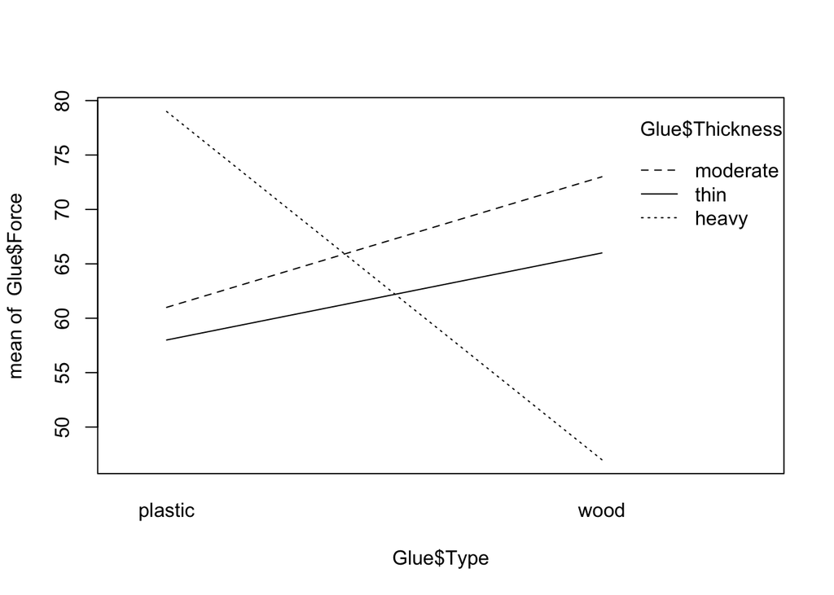

```r
#order is (FactorA, FactorB, Response)
interaction.plot(Glue$Type,Glue$Thickness,Glue$Force)
```

# Check and Compare Anova Models with Residual Analysis

Conditions for Anova (same for Linearity) (Check if some group si is more than twice another)

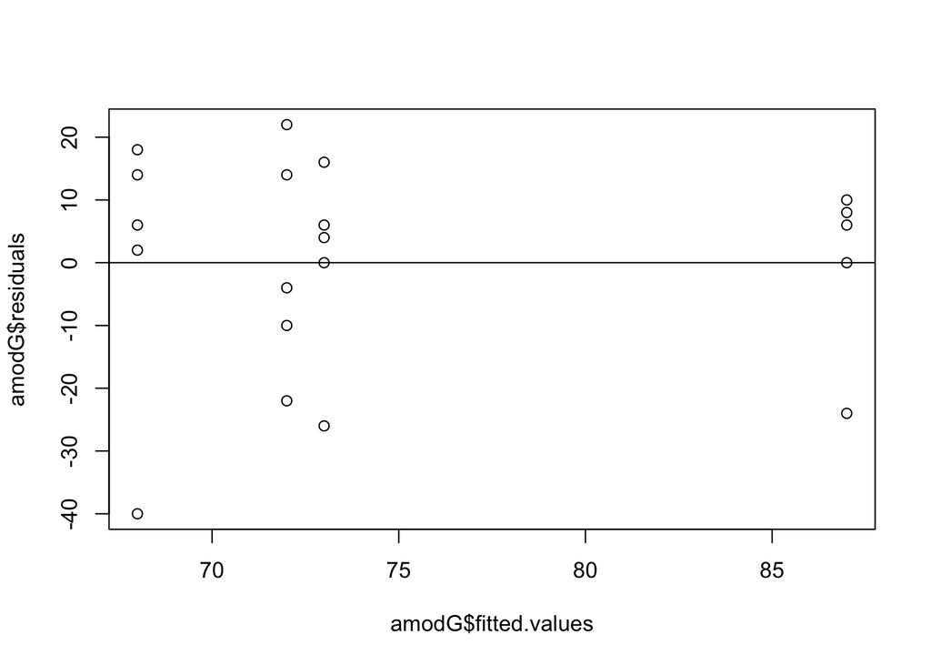

```r
plot(amodG$residuals~amodG$fitted.values)
abline(0,0)
```

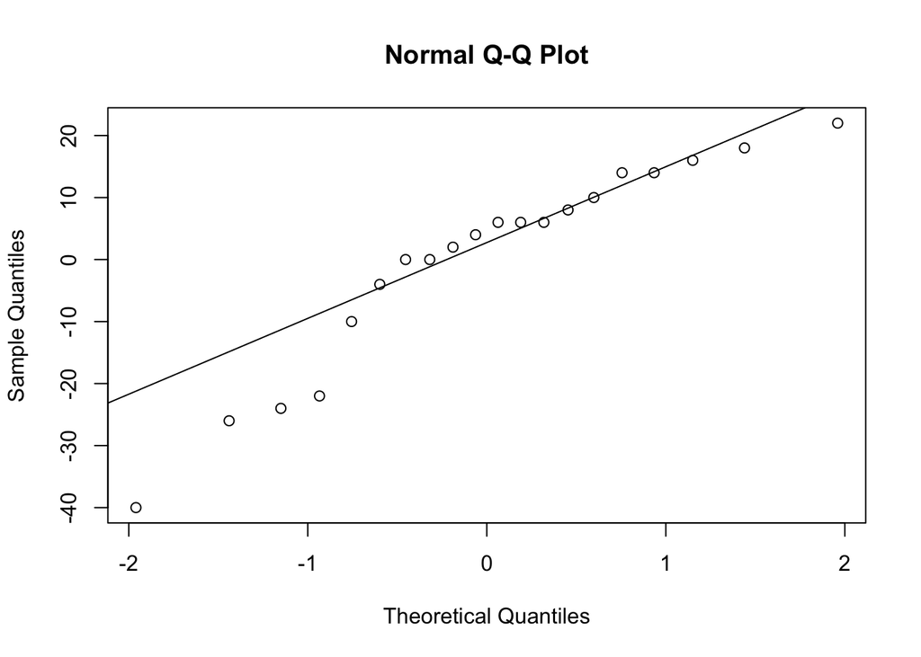

```r
qqnorm(amodG$residuals)
qqline(amodG$residuals)
```

Can visualize issues in Anova model with the tails/patterns that are visible in the residual graphs

## Anova via Dummy Regression

Create indicator predictors for each factor Run regression with the dummy predictors (leaving out one for each factor) To include interaction: Use products of the (included) dummies. How to interpret the coefficients? How to “recover” the three ANOVA components?

```r
#leave out Heavy of first factor
Thin=(Glue$Thickness=="thin")*1
Moderate=(Glue$Thickness=="moderate")*1

mod1=aov(Force~Thickness,data=Glue)
summary(mod1)
```

```
##             Df Sum Sq Mean Sq F value Pr(>F)
## Thickness    2     56    28.0   0.155  0.859
## Residuals    9   1628   180.9
```

```r
mod2=lm(Force~Thin+Moderate,data=Glue)
summary(mod2)
```

```
##
## Call:
## lm(formula = Force ~ Thin + Moderate, data = Glue)
##
## Residuals:
##    Min     1Q Median     3Q    Max
## -20.00 -10.50   0.50   9.25  23.00
##
## Coefficients:
##             Estimate Std. Error t value Pr(>|t|)
## (Intercept)   63.000      6.725   9.368 6.14e-06 ***
## Thin          -1.000      9.510  -0.105    0.919
## Moderate       4.000      9.510   0.421    0.684
## ---
## Signif. codes:  0 '***' 0.001 '**' 0.01 '*' 0.05 '.' 0.1 ' ' 1
##
## Residual standard error: 13.45 on 9 degrees of freedom
## Multiple R-squared:  0.03325,    Adjusted R-squared:  -0.1816
## F-statistic: 0.1548 on 2 and 9 DF,  p-value: 0.8588
```

```r
anova(mod2)
```

|  | Df | Sum Sq | Mean Sq | F value | Pr(>F) |
| --- | --- | --- | --- | --- | --- |
| Thin | 1 | 24 | 24.0000 | 0.1326781 | 0.7240822 |
| Moderate | 1 | 32 | 32.0000 | 0.1769042 | 0.6839122 |
| Residuals | 9 | 1628 | 180.8889 | NA | NA |

```r
#leave out plastic of second factor
Wood=(Glue$Type=="wood")*1

mod4=lm(Force~Moderate+Thin+Wood,data=Glue)
summary(mod4)
```

```
##
## Call:
## lm(formula = Force ~ Moderate + Thin + Wood, data = Glue)
##
## Residuals:
##    Min     1Q Median     3Q    Max
## -18.00 -10.50   0.00   8.25  21.00
##
## Coefficients:
##             Estimate Std. Error t value Pr(>|t|)
## (Intercept)   65.000      8.114   8.011 4.32e-05 ***
## Moderate       4.000      9.937   0.403    0.698
## Thin          -1.000      9.937  -0.101    0.922
## Wood          -4.000      8.114  -0.493    0.635
## ---
## Signif. codes:  0 '***' 0.001 '**' 0.01 '*' 0.05 '.' 0.1 ' ' 1
##
## Residual standard error: 14.05 on 8 degrees of freedom
## Multiple R-squared:  0.06176,    Adjusted R-squared:  -0.2901
## F-statistic: 0.1755 on 3 and 8 DF,  p-value: 0.91
```

```r
anova(mod4)
```

|  | Df | Sum Sq | Mean Sq | F value | Pr(>F) |
| --- | --- | --- | --- | --- | --- |
| Moderate | 1 | 54 | 54.0 | 0.27341772 | 0.6152170 |
| Thin | 1 | 2 | 2.0 | 0.01012658 | 0.9223197 |
| Wood | 1 | 48 | 48.0 | 0.24303797 | 0.6352663 |
| Residuals | 8 | 1580 | 197.5 | NA | NA |

```r
#incorporate interaction variables
mod6=lm(Force~Moderate+Thin+Wood+I(Moderate*Wood)+I(Thin*Wood),data=Glue)
summary(mod6)
```

```
##
## Call:
## lm(formula = Force ~ Moderate + Thin + Wood + I(Moderate * Wood) +
##     I(Thin * Wood), data = Glue)
##
## Residuals:
##    Min     1Q Median     3Q    Max
##     -7     -6      0      6      7
##
## Coefficients:
##                    Estimate Std. Error t value Pr(>|t|)
## (Intercept)          79.000      5.745  13.752 9.19e-06 ***
## Moderate            -18.000      8.124  -2.216  0.06861 .
## Thin                -21.000      8.124  -2.585  0.04149 *
## Wood                -32.000      8.124  -3.939  0.00763 **
## I(Moderate * Wood)   44.000     11.489   3.830  0.00866 **
## I(Thin * Wood)       40.000     11.489   3.482  0.01312 *
## ---
## Signif. codes:  0 '***' 0.001 '**' 0.01 '*' 0.05 '.' 0.1 ' ' 1
##
## Residual standard error: 8.124 on 6 degrees of freedom
## Multiple R-squared:  0.7648, Adjusted R-squared:  0.5689
## F-statistic: 3.903 on 5 and 6 DF,  p-value: 0.06386
```

```r
anova(mod6)
```

|  | Df | Sum Sq | Mean Sq | F value | Pr(>F) |
| --- | --- | --- | --- | --- | --- |
| Moderate | 1 | 54 | 54 | 0.81818182 | 0.40057186 |
| Thin | 1 | 2 | 2 | 0.03030303 | 0.86752938 |
| Wood | 1 | 48 | 48 | 0.72727273 | 0.42649491 |
| I(Moderate * Wood) | 1 | 384 | 384 | 5.81818182 | 0.05242444 |
| I(Thin * Wood) | 1 | 800 | 800 | 12.12121212 | 0.01311764 |
| Residuals | 6 | 396 | 66 | NA | NA |

```r
#Construct a two-way ANOVA w/interaction via dummy regression to investigate factors impacting weight loss after 6 weeks.
#Diet$weightloss = Diet$weight6weeks - Diet$pre.weight

#mod9=lm(weightloss~factor(Diet)+gender+factor(Diet)*gender, data=Diet)

#summary(mod9)
#anova(mod9)
```

## Ancova Modeling

If we can use dummy predictors to convert an ANOVA for means into a regression model, why not also include quantitative predictors?

Active = β0 + β1Rest + β2Exer1 + β3Exer2 + ε B0 and B1 are the Covariates and B2 and B3 are Factors

Look at the plots of One Way Anova. New condition to consider: Is there an interaction between the covariate and the factor?

```r
PulseF17 = read.csv("/Users/abwilli/Downloads/PulseF17.csv")
#one way anova test
modp = aov(Active~factor(Exercise), data = PulseF17)
summary(modp)
```

```
##                   Df Sum Sq Mean Sq F value   Pr(>F)
## factor(Exercise)   2  14342    7171   24.02 1.54e-10 ***
## Residuals        372 111050     299
## ---
## Signif. codes:  0 '***' 0.001 '**' 0.01 '*' 0.05 '.' 0.1 ' ' 1
```

```r
#Ancova model
modp2log = lm(log(Active)~Rest + factor(Exercise), data = PulseF17)
anova(modp2log)
```

|  | Df | Sum Sq | Mean Sq | F value | Pr(>F) |
| --- | --- | --- | --- | --- | --- |
| Rest | 1 | 6.70872309 | 6.70872309 | 278.032286 | 5.533084e-47 |
| factor(Exercise) | 2 | 0.07144875 | 0.03572437 | 1.480539 | 2.288560e-01 |
| Residuals | 371 | 8.95196851 | 0.02412930 | NA | NA |

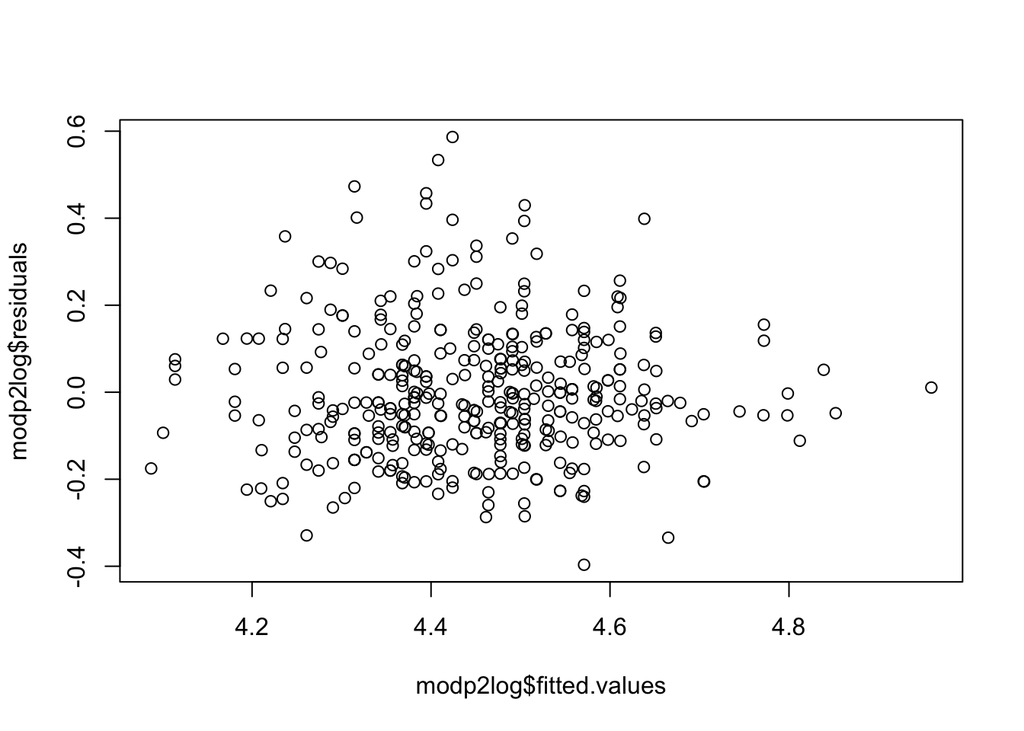

```r
plot(modp2log$residuals~modp2log$fitted.values)
```

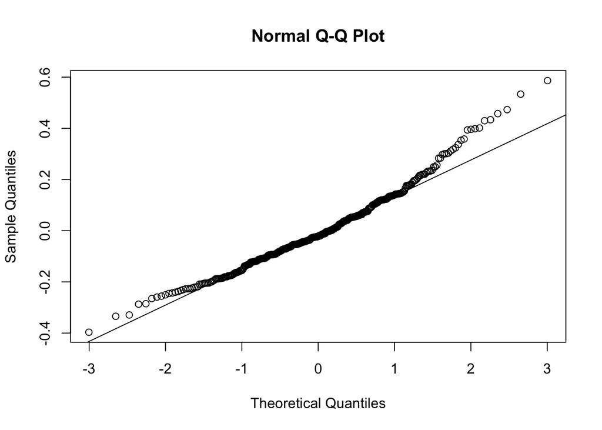

```r
qqnorm(modp2log$residuals)
qqline(modp2log$residuals)
```

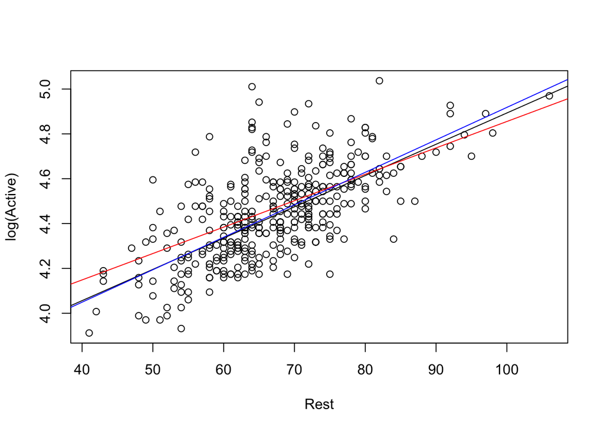

```r
#visualize interactions between covariate(Rest) and factors (exercise 1-3)
Exercise1 = subset(PulseF17, PulseF17$Exercise==1)
Exercise2 = subset(PulseF17, PulseF17$Exercise==2)
Exercise3= subset(PulseF17, PulseF17$Exercise==3)

lme1.log = lm(log(Active) ~ Rest, data=Exercise1)
lme2.log = lm(log(Active) ~ Rest, data=Exercise2)
lme3.log = lm(log(Active) ~ Rest, data=Exercise3)

plot(log(Active) ~ Rest, data=PulseF17)
abline(lme1.log)
abline(lme2.log, col='red')
abline(lme3.log, col='blue')
```